# Présentation des données

Savannah LAURENT

07/05/2022

À travers ce premier script, nous allons présenter deux types de données :

- les données de votes
- les données de carroyage

## 0.1 Données : *Votes*

> Le statisticien public utilise une matière première originale : les données. Mais outre celles qui sont issues d’enquêtes ou de déclarations administratives, il est amené à mobiliser des données d’autres natures, qui ne résultent pas toujours d’un processus d’observation. Comprendre ce matériau « data », c’est en explorer les principales dimensions, en s’appuyant sur le triplet <concept, domaine, valeur>. Toute donnée se caractérise par un vaste faisceau de conventions (sémantique, nomenclatures, formats, etc.), et par l’infrastructure de connaissances dans laquelle elle s’inscrit, impliquant des choix qui n’ont rien de neutre. Une donnée se révèle aussi dépendante de l’environnement qui lui a donné naissance, et des processus productifs qui l’utilisent. On constate alors que les données ne sont pas pures et parfaites, ne vont pas de soi : paradoxalement, les données ne sont pas données. Pour les besoins de la statistique publique, utiliser efficacement une telle matière requiert de démêler un entrelacs de conventions, et de construire une sorte d’appareil d’observation a posteriori , rigoureux sur les temporalités, et tenant compte de l’écosystème dans lequel la donnée externe s’inscrit.

*Pascal Rivière, chef de l’Inspection générale, Insee*

Les données des bureaux de vote de la ville de Bondy nous permettent de connaître la répartition des bureaux de vote, le nombre d’electeurs inscrits, le nombre de votants, le taux de participation, le nombre de votes nuls, le nombre de votes blancs ainsi que les résultats.

## 0.2 Données : *Carroyage*

> Les données carroyées sont des données diffusées sur une maille originale, ne correspondant à aucun découpage administratif ou historique connu : celle de carrés, dont les côtés peuvent aller de 200 mètres jusqu’à plusieurs kilomètres. Dans les zones urbaines, quand les découpages communaux sont trop imprécis pour analyser les phénomènes démographiques ou socio-économiques, l’assemblage des carreaux permet de fournir des informations précieuses. Pour produire ce type de données, l’Insee doit relever plusieurs défis : géolocaliser les informations pour les rattacher à des carreaux, développer une méthode garantissant la protection de la vie privée et le respect du secret statistique, mettre à disposition ces données sous une forme utilisable par des experts, mais également par des amateurs, curieux de mieux connaître leur territoire et d’en avoir un aperçu rapide et éclairant. Avec quelques exemples d’utilisation pour le déploiement de politiques publiques, l’article illustre les techniques mises en œuvre pour permettre la diffusion des données issues de sources socio-fiscales en 2019. À l’image d’une mosaïque, un carreau pris individuellement n’a pas de sens : c’est bien la proximité avec ses voisins qui va permettre à la réalité de prendre forme et au territoire de révéler la richesse et la complexité des phénomènes qui le traversent.

*Valérie Darriau, à la date de la rédaction de l’article, cheffe de la division Statistiques et analyses urbaines, Insee*

### 0.2.1 CARTE INSEE

Nous pouvons générer une carte du carroyage de la ville de Bondy grâce à la fonction : mf_map

Les carreaux blancs correspondent à des zones sans habitations : parcs, zone industrielle (abattoir, décharge,…)

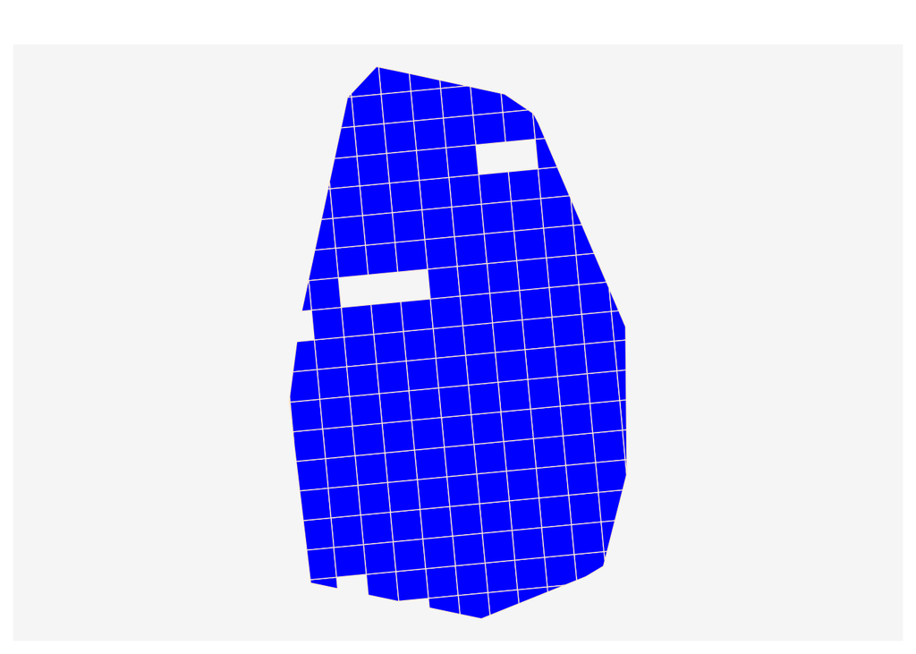